# Закономерности, определяющие успешность компьютерных игр

## Описание проекта

Мы работаем с данными из открытых источников по компьютерным играм до 2016 года. Наша цель - выявить определяющие успешность игры закономерности, которые помогут спланировать рекламные кампании на 2017 год.

Для этого мы проанализируем игры в срезе количества выпущенных в определённый период, в срезе продаж по платформам, определим актуальный период для работы, определим лидеров по продажам.  
Также в нашем распоряжении есть данные по возрастному рейтингу, оценки пользователей и критиков. Проанализируем их влияние на успешность игры и отражение успешности игры.  
Составим портрет пользователей в 3 регионах и определим доли продаж по платформам и жанрам.

## Обзор данных

Описание данных  
Name — название игры  
Platform — платформа  
Year_of_Release — год выпуска  
Genre — жанр игры  
NA_sales — продажи в Северной Америке (миллионы проданных копий)  
EU_sales — продажи в Европе (миллионы проданных копий)  
JP_sales — продажи в Японии (миллионы проданных копий)  
Other_sales — продажи в других странах (миллионы проданных копий)  
Critic_Score — оценка критиков (максимум 100)  
User_Score — оценка пользователей (максимум 10)  
Rating — рейтинг от организации ESRB (англ. Entertainment Software Rating Board). Эта ассоциация определяет рейтинг компьютерных игр и присваивает им подходящую возрастную категорию.  
Данные за 2016 год могут быть неполными.

```python
import pandas as pd
import matplotlib.pyplot as plt
import scipy.stats
```

```python
import warnings

warnings.filterwarnings('ignore')
```

```python
try:
    df = pd.read_csv('C://Users//79111//OneDrive//Рабочий стол//My_Folders//Practicum//Сборный проект 1//games.csv')
except:
    df = pd.read_csv('datasets/games.csv')
df.head()
```

|  | Name | Platform | Year_of_Release | Genre | NA_sales | EU_sales | JP_sales | Other_sales | Critic_Score | User_Score | Rating |
| --- | --- | --- | --- | --- | --- | --- | --- | --- | --- | --- | --- |
| 0 | Wii Sports | Wii | 2006.0 | Sports | 41.36 | 28.96 | 3.77 | 8.45 | 76.0 | 8 | E |
| 1 | Super Mario Bros. | NES | 1985.0 | Platform | 29.08 | 3.58 | 6.81 | 0.77 | NaN | NaN | NaN |
| 2 | Mario Kart Wii | Wii | 2008.0 | Racing | 15.68 | 12.76 | 3.79 | 3.29 | 82.0 | 8.3 | E |
| 3 | Wii Sports Resort | Wii | 2009.0 | Sports | 15.61 | 10.93 | 3.28 | 2.95 | 80.0 | 8 | E |
| 4 | Pokemon Red/Pokemon Blue | GB | 1996.0 | Role-Playing | 11.27 | 8.89 | 10.22 | 1.00 | NaN | NaN | NaN |

```python
df.info()
```

```
<class 'pandas.core.frame.DataFrame'>
RangeIndex: 16715 entries, 0 to 16714
Data columns (total 11 columns):
 #   Column           Non-Null Count  Dtype
---  ------           --------------  -----
 0   Name             16713 non-null  object
 1   Platform         16715 non-null  object
 2   Year_of_Release  16446 non-null  float64
 3   Genre            16713 non-null  object
 4   NA_sales         16715 non-null  float64
 5   EU_sales         16715 non-null  float64
 6   JP_sales         16715 non-null  float64
 7   Other_sales      16715 non-null  float64
 8   Critic_Score     8137 non-null   float64
 9   User_Score       10014 non-null  object
 10  Rating           9949 non-null   object
dtypes: float64(6), object(5)
memory usage: 1.4+ MB
```

Первое, что мы здесь видим: в оценках пользователей и критиков, а также в рейтинге очень много пропусков. Небольшое количество пропусков есть в Year_of_Release.  
Построим гистограммы для всех числовых столбцов.

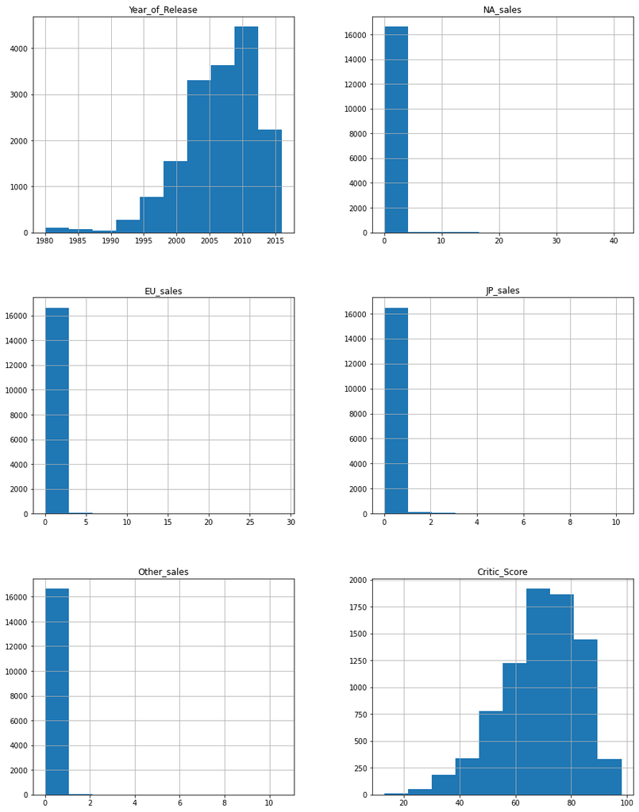

```python
df.hist(figsize=(15, 20))
plt.show()
```

Видим, что user_score здесь нет. Это связано с тем, что тип у него "объект". Надо будет изменить тип на числовой. На данном этапе многие из гистограмм не информативны.

## Подготовка данных

```python
# Привожу названия к нижнему регистру
df.columns = map(str.lower, df.columns)
df.head()
```

|  | name | platform | year_of_release | genre | na_sales | eu_sales | jp_sales | other_sales | critic_score | user_score | rating |
| --- | --- | --- | --- | --- | --- | --- | --- | --- | --- | --- | --- |
| 0 | Wii Sports | Wii | 2006.0 | Sports | 41.36 | 28.96 | 3.77 | 8.45 | 76.0 | 8 | E |
| 1 | Super Mario Bros. | NES | 1985.0 | Platform | 29.08 | 3.58 | 6.81 | 0.77 | NaN | NaN | NaN |
| 2 | Mario Kart Wii | Wii | 2008.0 | Racing | 15.68 | 12.76 | 3.79 | 3.29 | 82.0 | 8.3 | E |
| 3 | Wii Sports Resort | Wii | 2009.0 | Sports | 15.61 | 10.93 | 3.28 | 2.95 | 80.0 | 8 | E |
| 4 | Pokemon Red/Pokemon Blue | GB | 1996.0 | Role-Playing | 11.27 | 8.89 | 10.22 | 1.00 | NaN | NaN | NaN |

Посмотрим, что будет при переводе столбцов по продажам в целочисленный тип, посчитав, сколько строк будут равны 0 до и после операции.

```python
df[df['eu_sales'] == 0].shape[0]
```

```
5870
```

```python
df_1 = df
df_1['eu_sales'] = round(df['eu_sales']).astype(int)
df_1[df_1['eu_sales'] == 0].shape[0]
```

```
15646
```

Большая часть строк стала равна 0, что нас не устраивает. Посмотрим, что по остальным продажам.

```python
df.describe()
```

|  | year_of_release | na_sales | eu_sales | jp_sales | other_sales | critic_score |
| --- | --- | --- | --- | --- | --- | --- |
| count | 16446.000000 | 16715.000000 | 16715.000000 | 16715.000000 | 16715.000000 | 8137.000000 |
| mean | 2006.484616 | 0.263377 | 0.094287 | 0.077617 | 0.047342 | 68.967679 |
| std | 5.877050 | 0.813604 | 0.514560 | 0.308853 | 0.186731 | 13.938165 |
| min | 1980.000000 | 0.000000 | 0.000000 | 0.000000 | 0.000000 | 13.000000 |
| 25% | 2003.000000 | 0.000000 | 0.000000 | 0.000000 | 0.000000 | 60.000000 |
| 50% | 2007.000000 | 0.080000 | 0.000000 | 0.000000 | 0.010000 | 71.000000 |
| 75% | 2010.000000 | 0.240000 | 0.000000 | 0.040000 | 0.030000 | 79.000000 |
| max | 2016.000000 | 41.360000 | 29.000000 | 10.220000 | 10.570000 | 98.000000 |

### Пропуски

Смотрим количество пропусков с сортировкой по убыванию

```python
df.isna().sum().sort_values(ascending=False)
```

```
critic_score       8578
rating             6766
user_score         6701
year_of_release     269
name                  2
genre                 2
platform              0
na_sales              0
eu_sales              0
jp_sales              0
other_sales           0
dtype: int64
```

```python
# Проверю пропуски в %
pd.DataFrame(round(df.isna().mean()*100)).sort_values(by=0, ascending=False).style.background_gradient('coolwarm')
```

|  | 0 |
| --- | --- |
| critic_score | 51.000000 |
| user_score | 40.000000 |
| rating | 40.000000 |
| year_of_release | 2.000000 |
| name | 0.000000 |
| platform | 0.000000 |
| genre | 0.000000 |
| na_sales | 0.000000 |
| eu_sales | 0.000000 |
| jp_sales | 0.000000 |
| other_sales | 0.000000 |

В колонке year_of_release небольшое количество пропусков. Удалим их и поменяем тип на int

```python
df = df.dropna(subset=['year_of_release'])
df['year_of_release'] = df['year_of_release'].astype(int)
```

В 51% и 40% оценок критиков и пользователей у нас пропуски. Есть смысл заполнить их медианой или средним, как отображающими общую тенденцию. Это даст возможность лучше проанализировать данные.

Посмотрим уникальные значения в платформах и жанрах

```python
df['platform'].unique()
```

```
array(['Wii', 'NES', 'GB', 'DS', 'X360', 'PS3', 'PS2', 'SNES', 'GBA',
       'PS4', '3DS', 'N64', 'PS', 'XB', 'PC', '2600', 'PSP', 'XOne',
       'WiiU', 'GC', 'GEN', 'DC', 'PSV', 'SAT', 'SCD', 'WS', 'NG', 'TG16',
       '3DO', 'GG', 'PCFX'], dtype=object)
```

```python
df['genre'].unique()
```

```
array(['Sports', 'Platform', 'Racing', 'Role-Playing', 'Puzzle', 'Misc',
       'Shooter', 'Simulation', 'Action', 'Fighting', 'Adventure',
       'Strategy', nan], dtype=object)
```

Смотрим уникальные значения в оценках критиков и пользователей

```python
df['critic_score'].unique()
```

```
array([76., nan, 82., 80., 89., 58., 87., 91., 61., 97., 95., 77., 88.,
       83., 94., 93., 85., 86., 98., 96., 90., 84., 73., 74., 78., 92.,
       71., 72., 68., 62., 49., 67., 81., 66., 56., 79., 70., 59., 64.,
       75., 60., 63., 69., 50., 25., 42., 44., 55., 48., 57., 29., 47.,
       65., 54., 20., 53., 37., 38., 33., 52., 30., 32., 43., 45., 51.,
       40., 46., 39., 34., 41., 36., 31., 27., 35., 26., 19., 28., 23.,
       24., 21., 17., 13.])
```

```python
df['user_score'].unique()
```

```
array(['8', nan, '8.3', '8.5', '6.6', '8.4', '8.6', '7.7', '6.3', '7.4',
       '8.2', '9', '7.9', '8.1', '8.7', '7.1', '3.4', '5.3', '4.8', '3.2',
       '8.9', '6.4', '7.8', '7.5', '2.6', '7.2', '9.2', '7', '7.3', '4.3',
       '7.6', '5.7', '5', '9.1', '6.5', 'tbd', '8.8', '6.9', '9.4', '6.8',
       '6.1', '6.7', '5.4', '4', '4.9', '4.5', '9.3', '6.2', '4.2', '6',
       '3.7', '4.1', '5.8', '5.6', '5.5', '4.4', '4.6', '5.9', '3.9',
       '3.1', '2.9', '5.2', '3.3', '4.7', '5.1', '3.5', '2.5', '1.9', '3',
       '2.7', '2.2', '2', '9.5', '2.1', '3.6', '2.8', '1.8', '3.8', '0',
       '1.6', '9.6', '2.4', '1.7', '1.1', '0.3', '1.5', '0.7', '1.2',
       '2.3', '0.5', '1.3', '0.2', '0.6', '1.4', '0.9', '1', '9.7'],
      dtype=object)
```

В user_score видим значения tbd, надо будет посмотреть, что это значит. Посмотрим, сколько значений с tbd в оценках пользователей

```python
df.loc[df['user_score'] == 'tbd'].shape[0]
```

```
2376
```

Посмотрим, какие закономерности есть у строк с tbd  
Проверим предположение, что строки с tbd - это игры, которые не были выпущены в прокат, значит не имеют рейтинга (rating)

```python
df[df['user_score'] == 'tbd']['rating'].isna().sum()
```

```
50
```

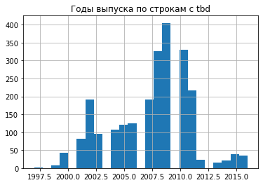

```python
df[df['user_score'] == 'tbd']['year_of_release'].hist(bins=25)
plt.title('Годы выпуска по строкам с tbd')
plt.show()
```

По гистограмме видим, что больше всего строк с tbd было в период с 2007 по 2011. Одной из причин этого может быть кризис 2008 года, от которого пострадала и игровая индустрия. Возможно, игры выходили недостаточным тиражом для оценки, или данные не собирались.  
Посмотрим, какой рейтинг у этих строк.

```python
df.loc[df['user_score'] == 'tbd'].groupby('rating')['user_score'].count().sort_values(ascending=False)
```

```
rating
E       1548
T        369
E10+     360
M         42
EC         7
Name: user_score, dtype: int64
```

Мы сгруппировали строки с tbd по rating. Большая часть строк - рейтинг E (Everyone — Для всех), дальше T (Teen — Подросткам) и E10+ (Everyone 10 and older — Для всех от 10 лет и старше).  
Посмотрим, что с рейтингом у строк без tbd.

```python
df.loc[df['user_score'] != 'tbd'].groupby('rating')['user_score'].count().sort_values(ascending=False)
```

```
rating
T       2518
E       2338
M       1492
E10+    1026
K-A        3
AO         1
EC         1
RP         1
Name: user_score, dtype: int64
```

Видим, что в строках без tbd также лидируют Т и Е.  
Посмотрим, есть ли оценка критиков в строках с tbd.

```python
df[
    (df['user_score'] == 'tbd') &
    (df['critic_score'].isna())
  ].shape[0]
```

```
1320
```

Видим распределение с и без оценок критиков, - примерно, 50 на 50.  
Посмотрим медиану, среднее, минимальное и максимальное значения оценки там, где она есть.

```python
print('Медиана оценок критиков в строках с tbd:', df[df['user_score'] == 'tbd']['critic_score'].median())
print('Среднее оценок критиков в строках с tbd:', df[df['user_score'] == 'tbd']['critic_score'].mean())
print('Максимальное значение оценок критиков в строках с tbd:', df[df['user_score'] == 'tbd']['critic_score'].max())
print('Минимальное значение оценок критиков в строках с tbd:', df[df['user_score'] == 'tbd']['critic_score'].min())
```

```
Медиана оценок критиков в строках с tbd: 62.0
Среднее оценок критиков в строках с tbd: 60.766098484848484
Максимальное значение оценок критиков в строках с tbd: 90.0
Минимальное значение оценок критиков в строках с tbd: 23.0
```

Разброс очень большой, медиана и среднее близки.  
Посмотрим моду по строкам с tbd

```python
print('Мода по жанру в строках с tbd:', df[df['user_score'] == 'tbd']['genre'].mode())
```

```
Мода по жанру в строках с tbd: 0    Misc
Name: genre, dtype: object
```

```python
print('Мода по платформе в строках с tbd:', df[df['user_score'] == 'tbd']['platform'].mode())
```

```
Мода по платформе в строках с tbd: 0    DS
Name: platform, dtype: object
```

Посмотрим количество строк с tbd с этими модами

```python
len(
    df[
        (df['user_score'] == 'tbd') &
        (df['genre'] == 'Misc') &
        (df['platform'] == 'DS')
    ])
```

```
142
```

Проверка на моду по жанрам и платформам для этих строк не показывает никаких ярких закономерностей.  
Посмотрим общее количество продаж по строкам с tbd и без. Для этого создадим столбец total_sales, куда объединим продажи по всем регионам

```python
df['total_sales'] = df[['na_sales', 'eu_sales', 'jp_sales', 'other_sales']].sum(axis=1)
df['total_sales'].head()
```

```
0    82.58
1    40.66
2    35.76
3    32.84
4    31.49
Name: total_sales, dtype: float64
```

```python
df[df['user_score'] == 'tbd']['total_sales'].describe()
```

```
count    2376.000000
mean        0.154327
std         0.279302
min         0.000000
25%         0.040000
50%         0.090000
75%         0.170000
max         7.110000
Name: total_sales, dtype: float64
```

```python
df[df['user_score'] != 'tbd']['total_sales'].describe()
```

```
count    14070.000000
mean         0.541357
std          1.677247
min          0.000000
25%          0.050000
50%          0.145000
75%          0.410000
max         82.580000
Name: total_sales, dtype: float64
```

Каких-то ярких закономерностей не видим. Возможно, рейтинг в этот период не собирался или был утерян.  
Переведём user_score в тип float, заменив tbd на NaN, чтобы посмотреть корреляцию и понять, по каким столбцам группировать для заполнения пропусков

```python
df['user_score'] = pd.to_numeric(df['user_score'], errors='coerce')
df['user_score'].head()
```

```
0    8.0
1    NaN
2    8.3
3    8.0
4    NaN
Name: user_score, dtype: float64
```

```python
df['user_score'].describe()
```

```
count    7463.000000
mean        7.126330
std         1.499447
min         0.000000
25%         6.400000
50%         7.500000
75%         8.200000
max         9.700000
Name: user_score, dtype: float64
```

Видим, что среднее и медиана очень близки.  
Построим диаграмму размаха

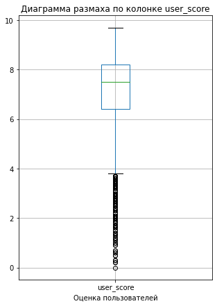

```python
df.boxplot(column = 'user_score', grid=True, figsize=(5,7))
plt.title('Диаграмма размаха по колонке user_score')
plt.xlabel('Оценка пользователей')
plt.show()
```

По диаграмме размаха видим, что выбросов довольно много. Поскольку медиана более устойчива к выбросам, будем заполнять пропуски ей, группируя по жанрам. Пропусков очень много, поэтому, чтобы оценить влияние заполнения и избежать ошибок, заполним пропуски в новом датафрейме (df_no_missing_values)

```python
df_no_missing_values = df.copy()
df_no_missing_values.head()
```

|  | name | platform | year_of_release | genre | na_sales | eu_sales | jp_sales | other_sales | critic_score | user_score | rating | total_sales |
| --- | --- | --- | --- | --- | --- | --- | --- | --- | --- | --- | --- | --- |
| 0 | Wii Sports | Wii | 2006 | Sports | 41.36 | 29 | 3.77 | 8.45 | 76.0 | 8.0 | E | 82.58 |
| 1 | Super Mario Bros. | NES | 1985 | Platform | 29.08 | 4 | 6.81 | 0.77 | NaN | NaN | NaN | 40.66 |
| 2 | Mario Kart Wii | Wii | 2008 | Racing | 15.68 | 13 | 3.79 | 3.29 | 82.0 | 8.3 | E | 35.76 |
| 3 | Wii Sports Resort | Wii | 2009 | Sports | 15.61 | 11 | 3.28 | 2.95 | 80.0 | 8.0 | E | 32.84 |
| 4 | Pokemon Red/Pokemon Blue | GB | 1996 | Role-Playing | 11.27 | 9 | 10.22 | 1.00 | NaN | NaN | NaN | 31.49 |

```python
u_score_median = df_no_missing_values.groupby('genre')['user_score'].median()
for t in u_score_median.index:
    df_no_missing_values.loc[
        (df_no_missing_values['user_score'].isna()) &
        (df_no_missing_values['genre'] == t),
        'user_score'] = df_no_missing_values.loc[df_no_missing_values['user_score'].isna(), 'user_score'] = u_score_median[t]
df_no_missing_values['user_score'].isna().sum()
```

```
0
```

Посмотрим среднее и медиану по колонке critic_score

```python
print('critic_score среднее:', df['critic_score'].mean())
print('critic_score медиана:', df['critic_score'].median())
```

```
critic_score среднее: 68.99436302142053
critic_score медиана: 71.0
```

```python
df['critic_score'].describe()
```

```
count    7983.000000
mean       68.994363
std        13.920060
min        13.000000
25%        60.000000
50%        71.000000
75%        79.000000
max        98.000000
Name: critic_score, dtype: float64
```

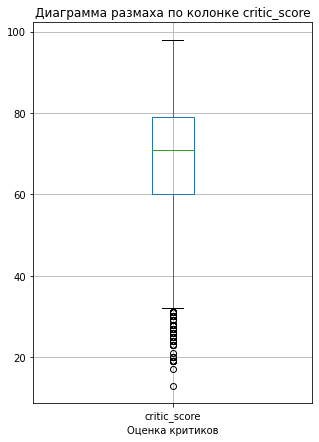

```python
df.boxplot(column = 'critic_score', grid=True, figsize=(5,7))
plt.title('Диаграмма размаха по колонке critic_score')
plt.xlabel('Оценка критиков')
plt.show()
```

По диаграмме размаха видим, что выбросы есть. Поскольку медиана более устойчива к выбросам, будем заполнять пропуские ей, группируя по жанрам. Пропусков очень много, поэтому, чтобы оценить влияние заполнения и избежать ошибок, заполним пропуски в новом датафрейме (df_no_missing_values)

```python
c_score_median = df_no_missing_values.groupby('genre')['critic_score'].median()
for t in c_score_median.index:
    df_no_missing_values.loc[
        (df_no_missing_values['critic_score'].isna()) &
        (df_no_missing_values['genre'] == t), 'critic_score'] = df_no_missing_values\
    .loc[df['critic_score'].isna(), 'critic_score'] =  c_score_median[t]
df_no_missing_values['critic_score'].isna().sum()
```

```
0
```

Посмотрим, что получилось после заполнения

```python
print(df_no_missing_values.groupby('genre')['critic_score'].median())
print(df_no_missing_values.groupby('genre')['user_score'].median())
```

```
genre
Action          73.0
Adventure       73.0
Fighting        73.0
Misc            73.0
Platform        73.0
Puzzle          73.0
Racing          73.0
Role-Playing    73.0
Shooter         73.0
Simulation      73.0
Sports          73.0
Strategy        73.0
Name: critic_score, dtype: float64
genre
Action          7.4
Adventure       7.4
Fighting        7.4
Misc            7.4
Platform        7.4
Puzzle          7.4
Racing          7.4
Role-Playing    7.4
Shooter         7.4
Simulation      7.4
Sports          7.4
Strategy        7.4
Name: user_score, dtype: float64
```

После заполнения пропусков мы получили одну медиану для всех жанров, что нас не устраивает. Возможно, это произошло из-за большого количества пропусков. Оставим датасет с пропусками.

## Исследовательский анализ данных

Посмотрим, сколько игр выпускалось в разные годы. Для этого построим столбчатую диаграмму.

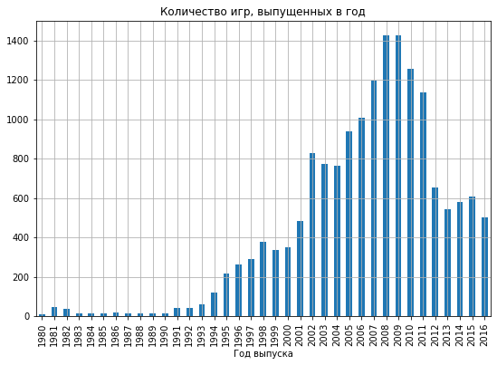

```python
df.pivot_table(index='year_of_release', values='name', aggfunc = 'count')\
.plot(kind='bar', figsize=(9,6), legend=False, grid=True)
plt.title('Количество игр, выпущенных в год')
plt.xlabel('Год выпуска')
plt.show()
```

Исходя из диаграммы можем сделать вывод, что данные за период до 2000 года можно не учитывать: в год выпускалось менее 400 игр. В нашем исследовании этот период не поможет.

Посмотрим, как менялись продажи по платформам. Для этого выберем платформы с наибольшими суммарными продажами.

```python
df.query('year_of_release >= 2000').groupby('platform')['total_sales'].sum().sort_values(ascending=False)
```

```
platform
PS2     1096.93
X360     874.92
PS3      840.13
Wii      834.86
DS       757.35
PS4      289.05
GBA      269.29
PSP      256.91
3DS      233.54
XB       209.92
GC       169.41
PC       158.38
XOne     141.73
PS       115.76
WiiU      70.06
PSV       43.74
N64       33.17
GB        30.81
DC         7.62
WS         0.96
Name: total_sales, dtype: float64
```

На основании группировки выбираем платформы с наибольшими суммарными продажами и строим распределение по годам.

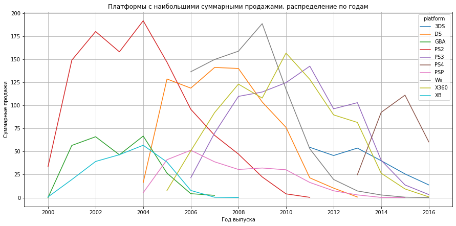

```python
df.query('platform == ["PS2", "X360", "PS3", "Wii", "DS", "PS4", "GBA", "PSP", "3DS", "XB"]') \
.pivot_table(index='year_of_release', columns='platform', values='total_sales', aggfunc='sum') \
.plot(figsize=(15,7), grid=True, xlim=(1999, 2017))
plt.title('Платформы с наибольшими суммарными продажами, распределение по годам')
plt.xlabel('Год выпуска')
plt.ylabel('Суммарные продажи')
plt.show()
```

Больше всего изменений в игровой индустрии, судя по платформам с наибольшими продажами, происходит, начиная с 2004 года: появляются несколько новых платформ, виден рост в продажах.  
График показывает спад в продажах, начиная с 2008 года. Платформы, с высокой прибыльностью в 2008-2011гг к 2012 падают в продажах. Эта тенденция характерна для всех платформ на графике. В период между 2011 и 2012гг появляется 3DS, в 2013г - PS4. PS2, DS уходят с рынка. На 2013 год есть лидеры по продажам: PS4, PS3, X360, 3DS.  
Здесь мы рассматриваем данные с 2000г и видим, что к 2013г многие топовые платформы перестали существовать или упали в продажах, появились новые. Вероятно, это связано с мировым экономическим кризисом, начавшимся в 2008 году.

Посчитаем средний срок жизни платформ. Возьмём платформы с наибольшими суммарными продажами

```python
platform_max = df.query('platform == ["PS2", "X360", "PS3", "Wii", "DS", "PS4", "GBA", "PSP", "3DS", "XB"]') \
.groupby('platform')['year_of_release'].max()
platform_min = df.query('platform == ["PS2", "X360", "PS3", "Wii", "DS", "PS4", "GBA", "PSP", "3DS", "XB"]') \
.groupby('platform')['year_of_release'].min()
platform_lifetime_mean = (platform_max - platform_min).mean()
print('Средний срок жизни платформ с наибольшими продажами:', platform_lifetime_mean)
```

```
Средний срок жизни платформ с наибольшими продажами: 10.4
```

Для прогноза на 2017 год будем брать данные за период с 2013 года: к этому моменту экономика справляется с основными последствиями кризиса. Так мы будем анализировать больше платформ, переживших кризис и работающих с новыми реалиями.  
Отфильтруем датасет, оставим данные только за актуальный период. Посмотрим, какие платформы лидируют по продажам, растут или падают. Выберем несколько потенциально прибыльных платформ.

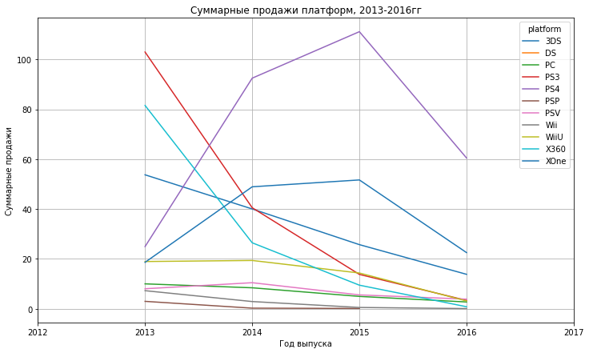

```python
up_to_date_df = df.loc[df['year_of_release'] >= 2013]
up_to_date_df.pivot_table(index='year_of_release', columns='platform', values='total_sales', aggfunc='sum') \
.plot(figsize=(12,7), grid=True, xlim=(2012, 2017))
plt.title('Суммарные продажи платформ, 2013-2016гг')
plt.xlabel('Год выпуска')
plt.ylabel('Суммарные продажи')
plt.show()
```

По графику видим, что к 2016 году у всех платформ идёт снижение в продажах. Но PS4, 3DS остаются в лидерах, также видим XOne, которая не попала в предыдущую выборку. PS3, X360 показывают резкое снижение.  
Итого к 2016 есть 3 лидера: PS4, 3DS, XOne. Их можно считать потенциально прибыльными.

Построим диаграмму размаха по глобальным продажам игр в разбивке по платформам

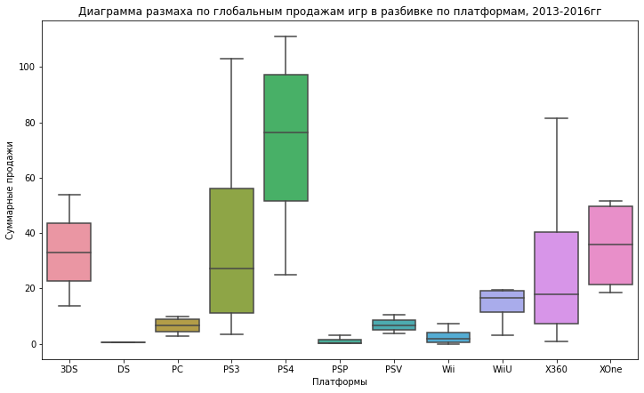

```python
import seaborn as sns
plt.figure(figsize=(12,7))
sns.boxplot(data=up_to_date_df
            .pivot_table(index='year_of_release', columns='platform', values='total_sales', aggfunc='sum'))
plt.title('Диаграмма размаха по глобальным продажам игр в разбивке по платформам, 2013-2016гг')
plt.xlabel('Платформы')
plt.ylabel('Суммарные продажи')
plt.show()
```

Посмотрим, как влияют на продажи внутри одной популярной платформы отзывы пользователей и критиков.  
Построим диаграмму рассеяния и посчитаем корреляцию между отзывами и продажами.

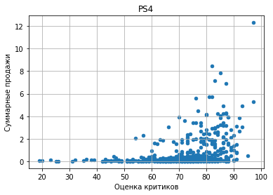

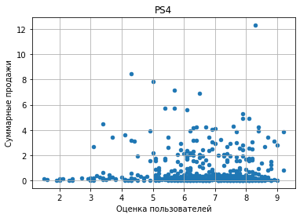

[figure not shown]

[figure not shown]

[figure not shown]

[figure not shown]

```python
platforms = ['PS4', '3DS', 'XOne']
for value in platforms:
    (up_to_date_df.query('platform == @platforms') \
    .plot(kind='scatter', x='critic_score', y='total_sales', grid=True, title=value, xlabel='Оценка критиков', \
          ylabel='Суммарные продажи')
           )
    (up_to_date_df.query('platform == @platforms') \
    .plot(kind='scatter', x='user_score', y='total_sales', grid=True, title=value, xlabel='Оценка пользователей', \
          ylabel='Суммарные продажи')
    )

    plt.show()
```

```python
print('Коэффициент корреляции между отзывами критиков и продажами PS4:', \
      up_to_date_df[up_to_date_df['platform'] == 'PS4']['critic_score'].corr(up_to_date_df['total_sales']).round(2))
print('Коэффициент корреляции между отзывами пользователей и продажами PS4:', \
      up_to_date_df[up_to_date_df['platform'] == 'PS4']['user_score'].corr(up_to_date_df['total_sales']).round(2))

print('Коэффициент корреляции между отзывами критиков и продажами 3DS:', \
      up_to_date_df[up_to_date_df['platform'] == '3DS']['critic_score'].corr(up_to_date_df['total_sales']).round(2))
print('Коэффициент корреляции между отзывами пользователей и продажами 3DS:', \
      up_to_date_df[up_to_date_df['platform'] == '3DS']['user_score'].corr(up_to_date_df['total_sales']).round(2))

print('Коэффициент корреляции между отзывами критиков и продажами XOne:', \
      up_to_date_df[up_to_date_df['platform'] == 'XOne']['critic_score'].corr(up_to_date_df['total_sales']).round(2))
print('Коэффициент корреляции между отзывами пользователей и продажами XOne:', \
      up_to_date_df[up_to_date_df['platform'] == 'XOne']['user_score'].corr(up_to_date_df['total_sales']).round(2))
```

```
Коэффициент корреляции между отзывами критиков и продажами PS4: 0.4
Коэффициент корреляции между отзывами пользователей и продажами PS4: -0.03
Коэффициент корреляции между отзывами критиков и продажами 3DS: 0.34
Коэффициент корреляции между отзывами пользователей и продажами 3DS: 0.25
Коэффициент корреляции между отзывами критиков и продажами XOne: 0.4
Коэффициент корреляции между отзывами пользователей и продажами XOne: -0.08
```

Из диаграмм и коэффициента видно, что корреляция как между отзывами критиков и продажами, так и между отзывами пользователей и продажами слабая положительная или отрицательная и минимальная. Возможно, это обусловлено большим числом пропусков в отзывах и разной ситуацией по разным регионам.

Посмотрим на общее распределение игр по жанрам. Выявим черты самых прибыльных жанров и посмотрим, выделяются ли жанры с высокими и низкими продажами. Для этого построим таблицу по прибыльности жанров, прибыльность будем оценивать по медианным продажам в разбивке по жанрам. Будем работать с медианой, так как она более устойчива к выбросам.  
Построим таблицу по медианным продажам и количеству выпущенных игр с сортировкой по убыванию по медианным продажам.

```python
genre_profitability_median = (
    up_to_date_df.groupby('genre')['total_sales', 'name']
                              .agg({'total_sales' : 'median', 'name' : 'count'}).round(2)
    .reset_index()
                             )
genre_profitability_median = (
    genre_profitability_median
    .rename(columns={'total_sales' : 'Глобальные медианные продажи', 'name' : 'Количество выпущенных игр'})
)
genre_profitability_median = genre_profitability_median.sort_values(by='Глобальные медианные продажи', ascending=False)
genre_profitability_median
```

|  | genre | Глобальные медианные продажи | Количество выпущенных игр |
| --- | --- | --- | --- |
| 8 | Shooter | 0.26 | 187 |
| 10 | Sports | 0.17 | 214 |
| 2 | Fighting | 0.12 | 80 |
| 4 | Platform | 0.12 | 74 |
| 7 | Role-Playing | 0.11 | 292 |
| 3 | Misc | 0.09 | 155 |
| 0 | Action | 0.08 | 766 |
| 5 | Puzzle | 0.06 | 17 |
| 11 | Strategy | 0.06 | 56 |
| 6 | Racing | 0.05 | 85 |
| 9 | Simulation | 0.03 | 62 |
| 1 | Adventure | 0.02 | 245 |

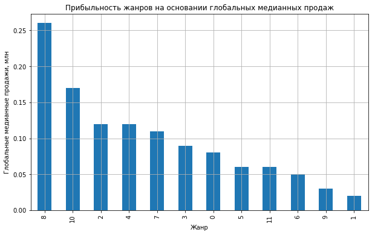

```python
genre_profitability_median['Глобальные медианные продажи'].plot(kind='bar', grid=True, figsize=(10,6))
plt.xlabel('Жанр')
plt.ylabel('Глобальные медианные продажи, млн')
plt.title('Прибыльность жанров на основании глобальных медианных продаж')
plt.show()
```

По графику выше видим, что в топ-5 жанров по медианным продажам вошли Shooter, Sports, Fighting, Platform, Role-Playing.  
Мы не стали выводить количество игр на жанр на графике, потому что тогда не было бы видно медианные продажи. Но, если посмотреть на таблицу genre_profitability_median, то мы видим, что жанр с наибольшим количеством игр (Action) даже не попал в топ-5. А Adventure, в котором игр выпущено больше, чем в топ-4 жанрах по прибыльности, занимает последнее место.  
Из этого можно сделать вывод, что связи между количеством выпущенных игр и прибыльностью нет.

## Составим портрет пользователя каждого региона

Определим для пользователя каждого региона (NA, EU, JP):  
Самые популярные платформы (топ-5). Опишем различия в долях продаж.

Для этого с помощью сводной таблицы найдём суммарные продажи по каждой платформе в этих трёх регионах, затем найдём доли продаж в каждом регионе. Отсортировав по суммарным продажам, мы выбирем топ-5 платформ

```python
sales_na_eu_jp = up_to_date_df.pivot_table(index='platform', values=['na_sales', 'eu_sales', 'jp_sales'], aggfunc='sum')
sales_na_eu_jp['overall_sales'] = sales_na_eu_jp['na_sales'] + sales_na_eu_jp['eu_sales'] + sales_na_eu_jp['jp_sales']
sales_na_eu_jp['eu_share'] = round(sales_na_eu_jp['eu_sales'] / sales_na_eu_jp['overall_sales'] * 100).astype(int)
sales_na_eu_jp['jp_share'] = round(sales_na_eu_jp['jp_sales'] / sales_na_eu_jp['overall_sales'] * 100).astype(int)
sales_na_eu_jp['na_share'] = round(sales_na_eu_jp['na_sales'] / sales_na_eu_jp['overall_sales'] * 100).astype(int)
sales_na_eu_jp = sales_na_eu_jp.sort_values(by='overall_sales', ascending=False)
sales_na_eu_jp.head(6)
```

| platform | eu_sales | jp_sales | na_sales | overall_sales | eu_share | jp_share | na_share |
| --- | --- | --- | --- | --- | --- | --- | --- |
| PS4 | 116 | 15.96 | 108.74 | 240.70 | 48 | 7 | 45 |
| PS3 | 47 | 23.35 | 63.50 | 133.85 | 35 | 17 | 47 |
| XOne | 34 | 0.34 | 93.12 | 127.46 | 27 | 0 | 73 |
| 3DS | 21 | 67.81 | 38.20 | 127.01 | 17 | 53 | 30 |
| X360 | 24 | 0.51 | 81.66 | 106.17 | 23 | 0 | 77 |
| WiiU | 11 | 10.88 | 29.21 | 51.09 | 22 | 21 | 57 |

Отфильтруем датафрейм, оставив топ-5 платформ

```python
sales_na_eu_jp = sales_na_eu_jp.loc[sales_na_eu_jp['overall_sales'] > 100]
sales_na_eu_jp
```

| platform | eu_sales | jp_sales | na_sales | overall_sales | eu_share | jp_share | na_share |
| --- | --- | --- | --- | --- | --- | --- | --- |
| PS4 | 116 | 15.96 | 108.74 | 240.70 | 48 | 7 | 45 |
| PS3 | 47 | 23.35 | 63.50 | 133.85 | 35 | 17 | 47 |
| XOne | 34 | 0.34 | 93.12 | 127.46 | 27 | 0 | 73 |
| 3DS | 21 | 67.81 | 38.20 | 127.01 | 17 | 53 | 30 |
| X360 | 24 | 0.51 | 81.66 | 106.17 | 23 | 0 | 77 |

Построим круговые диаграммы по долям продаж каждой платформы в 3 регионах

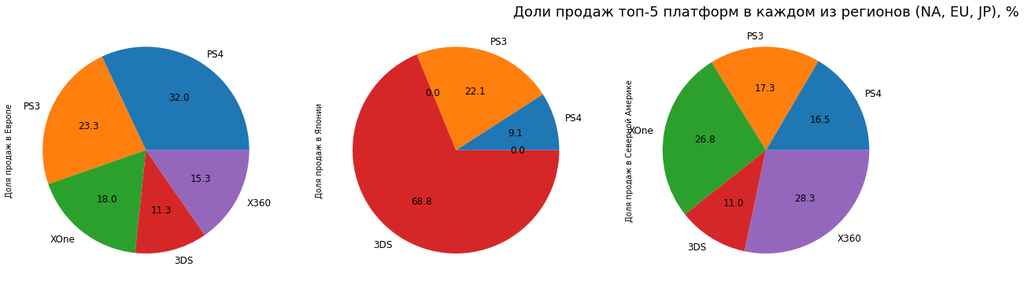

```python
sales_na_eu_jp.drop(columns=['eu_sales', 'jp_sales', 'na_sales', 'overall_sales']) \
.rename(columns={'eu_share' : 'Доля продаж в Европе', 'jp_share' : 'Доля продаж в Японии', \
                 'na_share': 'Доля продаж в Северной Америке'}) \
.plot(kind='pie', subplots=True, figsize=(20, 20), legend=False, fontsize=12, autopct='%.1f')
plt.title('Доли продаж топ-5 платформ в каждом из регионов (NA, EU, JP), %', fontsize=18)
plt.show()
```

В топ-5 платформ в Японии, Северной Америке, Европе вошли PS3, PS4, XOne, 3DS, X360. Для определения топ-5 мы работали с продажами, потому что в нашем датасете это единственные данные, разбитые по регионам.  
Если посмотреть на топ-5 платформ, которые мы отбирали по глобальным продажам в период с 2013г, то мы увидим лидирующие по продажам PS4, XOne, 3DS, а также PS3, X360, которые показывают резкое снижение в продажах, и на глобальном уровне не выглядят, как прибыльные к 2016 году. Хотя на 2013 год PS3, X360 показывали топовые продажи.

Определим самые популярные жанры (топ-5). Ориентироваться будем также на продажи.  
Для этого с помощью сводной таблицы найдём суммарные продажи по каждому жанру в трёх регионах, затем найдём доли продаж в каждом регионе. Отсортировав по суммарным продажам, мы выбирем топ-5 жанров

```python
sales_na_eu_jp_genre = up_to_date_df.pivot_table(index='genre', values=['na_sales', 'eu_sales', 'jp_sales'], aggfunc='sum')
sales_na_eu_jp_genre['overall_sales'] = \
sales_na_eu_jp_genre['na_sales'] + sales_na_eu_jp_genre['eu_sales'] + sales_na_eu_jp_genre['jp_sales']
sales_na_eu_jp_genre['eu_share'] = round(sales_na_eu_jp_genre['eu_sales'] / sales_na_eu_jp_genre['overall_sales'] * 100) \
.astype(int)
sales_na_eu_jp_genre['jp_share'] = round(sales_na_eu_jp_genre['jp_sales'] / sales_na_eu_jp_genre['overall_sales'] * 100) \
.astype(int)
sales_na_eu_jp_genre['na_share'] = round(sales_na_eu_jp_genre['na_sales'] / sales_na_eu_jp_genre['overall_sales'] * 100) \
.astype(int)
sales_na_eu_jp_genre = sales_na_eu_jp_genre.sort_values(by='overall_sales', ascending=False)
sales_na_eu_jp_genre.head(6)
```

| genre | eu_sales | jp_sales | na_sales | overall_sales | eu_share | jp_share | na_share |
| --- | --- | --- | --- | --- | --- | --- | --- |
| Action | 72 | 40.49 | 126.05 | 238.54 | 30 | 17 | 53 |
| Shooter | 70 | 6.61 | 109.74 | 186.35 | 38 | 4 | 59 |
| Role-Playing | 22 | 51.04 | 46.40 | 119.44 | 18 | 43 | 39 |
| Sports | 45 | 5.41 | 65.27 | 115.68 | 39 | 5 | 56 |
| Misc | 15 | 9.20 | 27.49 | 51.69 | 29 | 18 | 53 |
| Platform | 12 | 4.79 | 18.14 | 34.93 | 34 | 14 | 52 |

Отфильтруем датафрейм, оставив топ-5 жанров

```python
sales_na_eu_jp_genre = sales_na_eu_jp_genre.loc[sales_na_eu_jp_genre['overall_sales'] > 35]
sales_na_eu_jp_genre
```

| genre | eu_sales | jp_sales | na_sales | overall_sales | eu_share | jp_share | na_share |
| --- | --- | --- | --- | --- | --- | --- | --- |
| Action | 72 | 40.49 | 126.05 | 238.54 | 30 | 17 | 53 |
| Shooter | 70 | 6.61 | 109.74 | 186.35 | 38 | 4 | 59 |
| Role-Playing | 22 | 51.04 | 46.40 | 119.44 | 18 | 43 | 39 |
| Sports | 45 | 5.41 | 65.27 | 115.68 | 39 | 5 | 56 |
| Misc | 15 | 9.20 | 27.49 | 51.69 | 29 | 18 | 53 |

Построим круговые диаграммы по долям продаж каждого жанра в 3 регионах

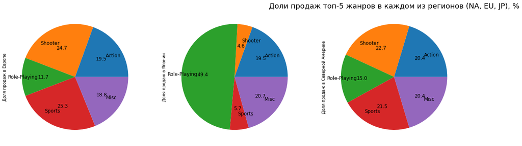

```python
sales_na_eu_jp_genre.drop(columns=['eu_sales', 'jp_sales', 'na_sales', 'overall_sales']) \
.rename(columns={'eu_share' : 'Доля продаж в Европе', 'jp_share' : 'Доля продаж в Японии', \
                 'na_share': 'Доля продаж в Северной Америке'}) \
.plot(kind='pie', subplots=True, figsize=(20, 20), legend=False, fontsize=12, autopct='%.1f', labeldistance=0.7)
plt.xticks(rotation=90)
plt.title('Доли продаж топ-5 жанров в каждом из регионов (NA, EU, JP), %', fontsize=18)
plt.show()
```

Топ-5 прибыльных жанров по медианным глобальным продажам (график "Прибыльность жанров на основании глобальных медианных продаж"):

1. Shooter
2. Sports
3. Fighting
4. Platform
5. Role-Playing

Посмотрим, влияет ли рейтинг ESRB на продажи в отдельном регионе

```python
up_to_date_df.pivot_table(index='rating', values=['na_sales', 'eu_sales', 'jp_sales'], aggfunc='sum')
```

| rating | eu_sales | jp_sales | na_sales |
| --- | --- | --- | --- |
| E | 64 | 15.14 | 79.05 |
| E10+ | 15 | 5.89 | 54.24 |
| M | 114 | 14.11 | 165.21 |
| T | 23 | 20.59 | 49.79 |

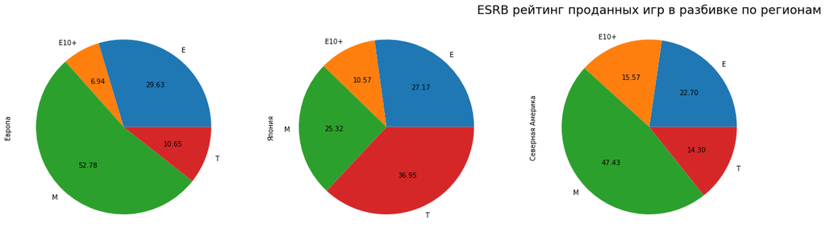

```python
up_to_date_df.pivot_table(index='rating', values=['na_sales', 'eu_sales', 'jp_sales'], aggfunc='sum') \
.rename(columns={'na_sales' : 'Северная Америка', 'eu_sales' : 'Европа', 'jp_sales' : 'Япония'}) \
.plot(kind='pie', subplots=True, figsize=(20,20), legend=False, autopct='%.2f')
plt.title('ESRB рейтинг проданных игр в разбивке по регионам', fontsize=18)
plt.show()
```

## Проверим гипотезы

Проверим гипотезу о том, что средние пользовательские рейтинги платформ Xbox One и PC одинаковые.  
Но: средние пользовательские рейтинги платформ Xbox One и PC равны.  
Н1: средние пользовательские рейтинги платформ Xbox One и PC не равны.  
У нас около половины пропусков в рейтингах. Посмотрим, сколько пропуcков в этих платформах.

```python
def precheck(df1, df2):
# Избавимся от пропусков
    df1 = df1.fillna(-1)
    df2 = df2.fillna(-1)
# Через фильтрацию избавимся от строк с плейсхолдером
    df1 = df1[df1 != -1].reset_index(drop=True)
    df2 = df2[df2 != -1].reset_index(drop=True)
# Посмотри, сколько строк осталось после удаления пропусков и плейсхолдера и равна ли дисперсия у датафреймов
    if df1.shape[0] >= 100:
        print('Строк в выборке больше 100, что достаточно для двухвыборочного t-теста')
    else:
        print('Строк недостаточно для двухвыборочного t-теста')
    if df2.shape[0] >= 100:
        print('Строк в выборке больше 100, что достаточно для двухвыборочного t-теста')
    else:
        print('Строк недостаточно для двухвыборочного t-теста')
# Проверим, равна ли дисперсия датафреймов
    print('Дисперсия датафреймов равна:', df1.var() == df2.var())
# Проверим гипотезу о равенстве средних с помощью двухвыборочного t-теста
    results_platform = scipy.stats.ttest_ind(df1, df2, equal_var=False)
    print('p-значение:', results_platform.pvalue.round(3))
# Зададим критерий значимости и проверим гипотезы
    alpha = 0.05
    if results_platform.pvalue < alpha:
        print('Отвергаем нулевую гипотезу')
    else:
        print('Не получилось отвергнуть нулевую гипотезу')
```

```python
XOne = up_to_date_df[up_to_date_df['platform'] == 'XOne']['user_score'].copy().reset_index(drop=True)
PC = up_to_date_df[up_to_date_df['platform'] == 'PC']['user_score'].copy().reset_index(drop=True)
```

```python
precheck(XOne, PC)
```

```
Строк в выборке больше 100, что достаточно для двухвыборочного t-теста
Строк в выборке больше 100, что достаточно для двухвыборочного t-теста
Дисперсия датафреймов равна: False
p-значение: 0.148
Не получилось отвергнуть нулевую гипотезу
```

Проверим гипотезу о том, что пользовательские рейтинги жанров Action (англ. «действие», экшен-игры) и Sports (англ. «спортивные соревнования») разные.  
Но: средние пользовательские рейтинги жанров Action и Sports равны.  
Н1: средние пользовательские рейтинги жанров Action и Sports не равны.  
Выполним те же шаги, что для платформ

```python
action = up_to_date_df[up_to_date_df['genre'] == 'Action']['user_score'].copy().reset_index(drop=True)
sports = up_to_date_df[up_to_date_df['genre'] == 'Sports']['user_score'].copy().reset_index(drop=True)
```

```python
precheck(action, sports)
```

```
Строк в выборке больше 100, что достаточно для двухвыборочного t-теста
Строк в выборке больше 100, что достаточно для двухвыборочного t-теста
Дисперсия датафреймов равна: False
p-значение: 0.0
Отвергаем нулевую гипотезу
```

Для жанров и платформ мы формулировали нулевую гипотезу исходя из того, что Н0 всегда утверждает отсутствие разницы. Так как мы проверяли гипотезу о разнице между средними двух независимых выборок, мы использовали двухвыборочный t-тест, также мы проверили равенство дисперсий (они не равны) и отразили это в тесте.  
Нам не удалось отвергнуть нулевую гипотезу о том, что средние пользовательские рейтинги платформ Xbox One и PC равны.  
И удалось отвергнуть нулевую гипотезу о том, что средние пользовательские рейтинги жанров Action и Sports равны.